# R Notebook

[output not shown]

````
```r
```r
NY_counties <- counties(state = \NY\, cb = TRUE) # cb = TRUE specifies to download a lower resolution file (faster download)
````

[output not shown]

````
```r
```r
NY_roads <- tigris::primary_roads()
````

[output not shown]

````
```r
```r
NY_counties <- st_as_sf(NY_counties) # convert to an sf object
````

````
```r
```r
NY_counties %>%
  #filter(NAME == \Schenectady\) %>%

  tm_shape() +
  tm_borders() +

  tm_shape(NY_roads) +
  tm_lines() +

  tm_shape(sf_soil_pb) +
  tm_dots(col = \Top5_Pb\, style = \quantile\, palette = \viridis\, size = 0.75)
````

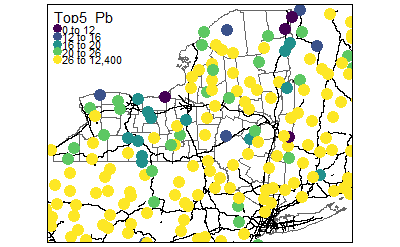